# Pertemuan 2

Megawati Roito Panjaitan

2023-09-10

## 1. Pendahuluan

### 1.1 Library yang digunakan

```r
library(dplyr)
library(TTR)
library(forecast)
library(lmtest)
library(orcutt)
library(HoRM)
library(rio)
```

### 1.2 Input data

```r
data<-import("https://raw.githubusercontent.com/panjaitanroito/Praktikum-MPDW/main/Pertemuan%202/pertemuan%202.csv")
```

### 1.3 Eksplorasi data

```r
View(data)
str(data)
```

```
## 'data.frame':    200 obs. of  6 variables:
##  $ period: int  1 2 3 4 5 6 7 8 9 10 ...
##  $ open  : num  14.9 15.1 15.5 15.7 15.8 ...
##  $ high  : num  15 15.4 15.8 15.9 15.9 ...
##  $ low   : num  14.8 15 15.4 15.7 15.7 ...
##  $ close : num  15 15.3 15.7 15.8 15.8 ...
##  $ volume: int  6051569 6027549 8434475 5123643 4245786 5720973 6732709 7190835 5127286 4911752 ...
```

```r
dim(data)
```

```
## [1] 200   6
```

```r
data.ts <- ts(data$close)
summary(data.ts)
```

```
##    Min. 1st Qu.  Median    Mean 3rd Qu.    Max.
##   13.75   15.32   16.32   15.96   16.86   17.29
```

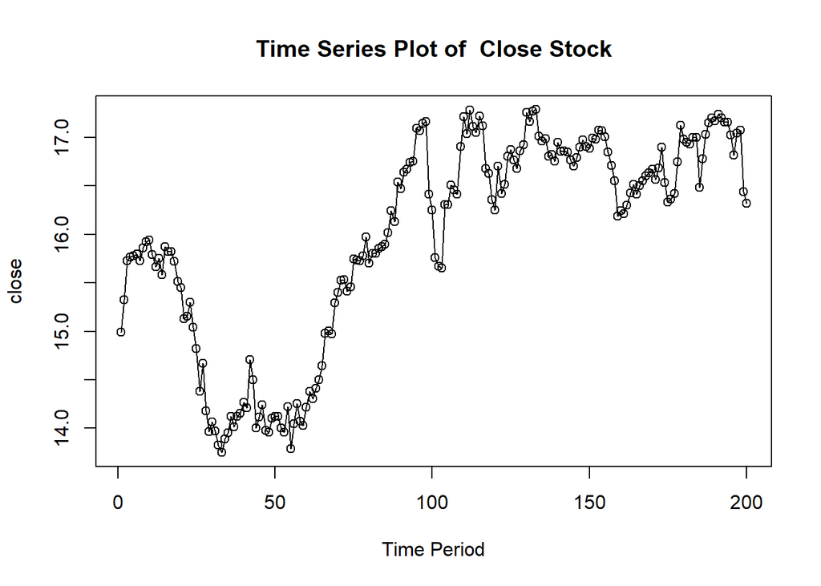

```r
ts.plot(data.ts, xlab="Time Period", ylab="close",
        main = "Time Series Plot of  Close Stock")
points(data.ts)
```

### 1.4 Model Regresi

```r
y<-data$close
x1<-data$open
x2<-data$high
x3<-data$low
model<- lm(y~x1+x2+x3 ,data = data)
summary(model)
```

```
##
## Call:
## lm(formula = y ~ x1 + x2 + x3, data = data)
##
## Residuals:
##       Min        1Q    Median        3Q       Max
## -0.201542 -0.048467  0.007947  0.046109  0.206906
##
## Coefficients:
##             Estimate Std. Error t value Pr(>|t|)
## (Intercept)  0.07840    0.08433   0.930    0.354
## x1          -0.53091    0.05588  -9.502   <2e-16 ***
## x2           0.81799    0.05483  14.917   <2e-16 ***
## x3           0.70703    0.05089  13.894   <2e-16 ***
## ---
## Signif. codes:  0 '***' 0.001 '**' 0.01 '*' 0.05 '.' 0.1 ' ' 1
##
## Residual standard error: 0.07805 on 196 degrees of freedom
## Multiple R-squared:  0.9948, Adjusted R-squared:  0.9947
## F-statistic: 1.245e+04 on 3 and 196 DF,  p-value: < 2.2e-16
```

## 2. Mendeteksi Autokorelasi

### 2.1 Diagnostik dengan Eksploratif

#### 2.1.1. Plot Residual vs Order

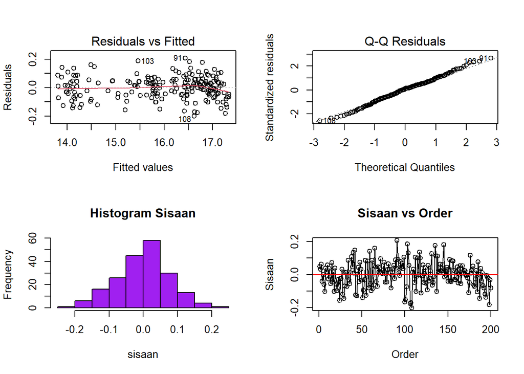

```r
sisaan<- residuals(model)
par(mfrow = c(2,2))
plot(model, which=1:2)
hist(sisaan, col="purple", main="Histogram Sisaan")
plot(sisaan,type="o",
     ylab="Sisaan", xlab="Order", main="Sisaan vs Order")
abline(h=0, col='red')
```

Keempat chart di atas diperlukan untuk memeriksa asumsi regresi. Pada plot Sisaan vs Order terlihat pola naik turun yang menunjukkan bahwa sisaan dari galatnya tidak saling bebas atau ada autokorelasi.

#### 2.1.2 ACF dan PACF

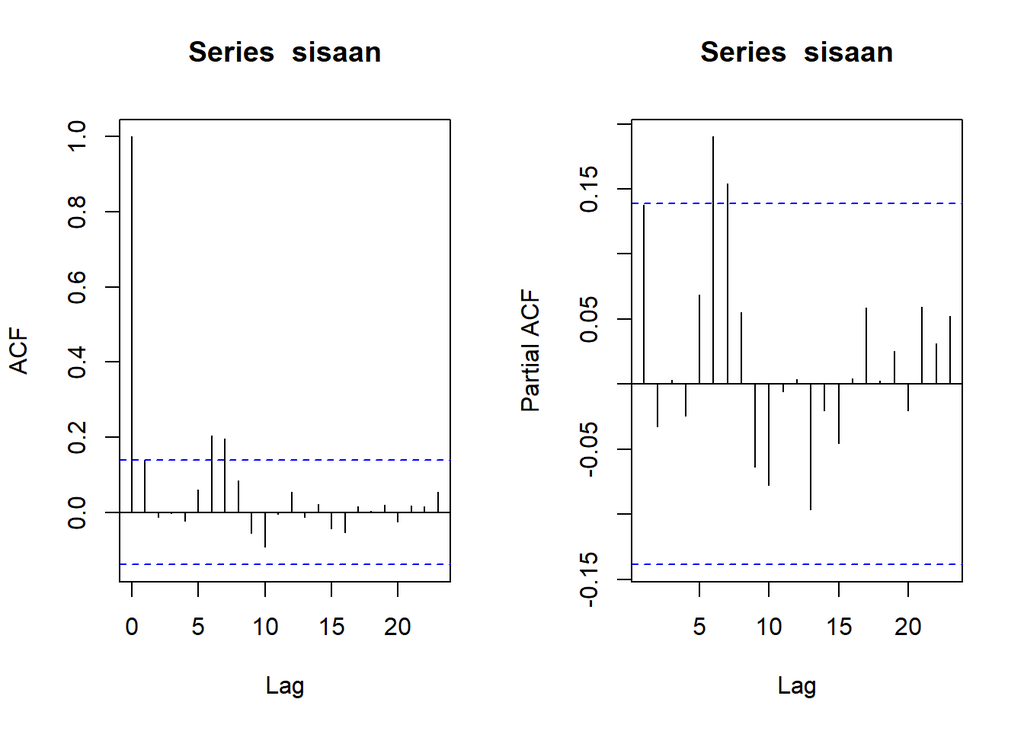

```r
par(mfrow = c(1,2))
acf(sisaan)
pacf(sisaan)
```

Pada plot ACF dan PACF terlihat bahwa ada garis vertikal di lag tertentu yang melebihi batas garis biru horizontal. Artinya, dapat dikatakan bahwa ada autokorelasi pada model.

### 2.2 Uji Formal

Uji formal dilakukan menggunakan Uji Durbin Watson, dengan hipotesis berikut.

```r
#H0: tidak ada autokorelasi
#H1: ada autokorelasi
dwtest(model)
```

```
##
##  Durbin-Watson test
##
## data:  model
## DW = 1.7168, p-value = 0.01753
## alternative hypothesis: true autocorrelation is greater than 0
```

Berdasarkan hasil DW Test, diperoleh nilai DW = 1.7168 dan *p-value* =$0.01753$. Berdasarkan tabel Durbin-Watson diperoleh nilai $DL = 1.7279$ dan $DU = 1.8094$. Nilai DW berada di luar rentang DL dan DU, serta *p-value*< 0.05 sehingga dapat disimpulkan bahwa tolak H0, artinya cukup bukti untuk mengatakan bahwa terdapat autokorelasi pada taraf 5%. Oleh karena itu, diperlukan penangan autokorelasi. Penanganan yang akan digunakan menggunakan dua metode, yaitu Cochrane-Orcutt dan Hildret-Lu.

## 3. Penanganan Autokorelasi

### 3.1 Metode Cochrane-Orcutt

```r
#Penanganan Autokorelasi Cochrane-Orcutt
modelCO<-cochrane.orcutt(model)
modelCO
```

```
## Cochrane-orcutt estimation for first order autocorrelation
##
## Call:
## lm(formula = y ~ x1 + x2 + x3, data = data)
##
##  number of interaction: 7
##  rho 0.148144
##
## Durbin-Watson statistic
## (original):    1.71675 , p-value: 1.753e-02
## (transformed): 1.98768 , p-value: 4.39e-01
##
##  coefficients:
## (Intercept)          x1          x2          x3
##    0.086472   -0.525689    0.836317    0.682585
```

```r
#Rho optimum
rho<- modelCO$rho
rho
```

```
## [1] 0.1481436
```

```r
#Transformasi Manual
y.trans<- y[-1]-y[-200]*rho
x1.trans<-x1[-1]-x1[-200]*rho
x2.trans<-x2[-1]-x2[-200]*rho
x3.trans<-x3[-1]-x3[-200]*rho
```

```r
#Model transformasi
modelCOmanual<- lm(y.trans~x1.trans+x2.trans+x3.trans)
summary(modelCOmanual)
```

```
##
## Call:
## lm(formula = y.trans ~ x1.trans + x2.trans + x3.trans)
##
## Residuals:
##       Min        1Q    Median        3Q       Max
## -0.186501 -0.050141  0.008774  0.049497  0.199535
##
## Coefficients:
##             Estimate Std. Error t value Pr(>|t|)
## (Intercept)  0.07366    0.08329   0.884    0.378
## x1.trans    -0.52569    0.05512  -9.537   <2e-16 ***
## x2.trans     0.83632    0.05466  15.302   <2e-16 ***
## x3.trans     0.68258    0.05169  13.206   <2e-16 ***
## ---
## Signif. codes:  0 '***' 0.001 '**' 0.01 '*' 0.05 '.' 0.1 ' ' 1
##
## Residual standard error: 0.07737 on 195 degrees of freedom
## Multiple R-squared:  0.993,  Adjusted R-squared:  0.9929
## F-statistic:  9203 on 3 and 195 DF,  p-value: < 2.2e-16
```

```r
#Menguji autokorelasi model transformasi
#H0: tidak ada autokorelasi
#H1: ada autokorelasi
dwtest(modelCOmanual,alternative='two.sided')
```

```
##
##  Durbin-Watson test
##
## data:  modelCOmanual
## DW = 1.9877, p-value = 0.878
## alternative hypothesis: true autocorrelation is not 0
```

Berdasarkan hasil di atas diperoleh nilai p-value > 0.05, sehingga tidak tolak H0. Artinya, tidak ada autokorelasi atau terbukti bahwa autokorelasi telah berhasil ditangani menggunakan metode Cochrane-Orcutt.

```r
#Transformasi balik
(b0 <- modelCOmanual$coefficients[1]/(1-rho))
```

```
## (Intercept)
##  0.08647215
```

```r
(b1<- modelCOmanual$coefficients[2])
```

```
##   x1.trans
## -0.5256894
```

```r
(b2<-modelCOmanual$coefficients[3])
```

```
##  x2.trans
## 0.8363174
```

```r
(b4<-modelCOmanual$coefficients[4])
```

```
##  x3.trans
## 0.6825848
```

Setelah dilakukan transformasi balik, diperoleh model regresi baru yaitu:
$$y_i= 0.08647215-0.5256894
x_1+0.8363174x_2+0.6825848x_3$$

### 3.2 Metode Hildreth-lu

```r
#Penanganan autokorelasi Hildreth-lu
hildreth.lu.func<- function(r, model){
  x1 <- model.matrix(model)[,2]
  x2 <- model.matrix(model)[,3]
  x3 <- model.matrix(model)[,4]

  y <- model.response(model.frame(model))
  n <- length(y)
  t <- 2:n
  y <- y[t]-r*y[t-1]
  x1 <- x1[t]-r*x1[t-1]
  x2 <- x2[t]-r*x2[t-1]
  x3 <- x3[t]-r*x3[t-1]

  return(lm(y~x1+x2+x3))
}
```

```r
#Pencarian rho yang meminimumkan SSE
r <- c(seq(0.1,0.9, by= 0.1))
tab <- data.frame("rho" = r, "SSE" = sapply(r, function(i){deviance(hildreth.lu.func(i, model))}))
round(tab, 4)
```

```
##   rho    SSE
## 1 0.1 1.1698
## 2 0.2 1.1702
## 3 0.3 1.1925
## 4 0.4 1.2364
## 5 0.5 1.3010
## 6 0.6 1.3840
## 7 0.7 1.4791
## 8 0.8 1.5696
## 9 0.9 1.6261
```

```r
#rho optimal di sekitar 0.1
rOpt <- seq(0.07,0.2, by=0.001)
tabOpt <- data.frame("rho" = rOpt, "SSE" = sapply(rOpt, function(i){deviance(hildreth.lu.func(i, model))}))
head(tabOpt[order(tabOpt$SSE),])
```

```
##      rho      SSE
## 79 0.148 1.167269
## 80 0.149 1.167270
## 78 0.147 1.167270
## 81 0.150 1.167273
## 77 0.146 1.167274
## 82 0.151 1.167278
```

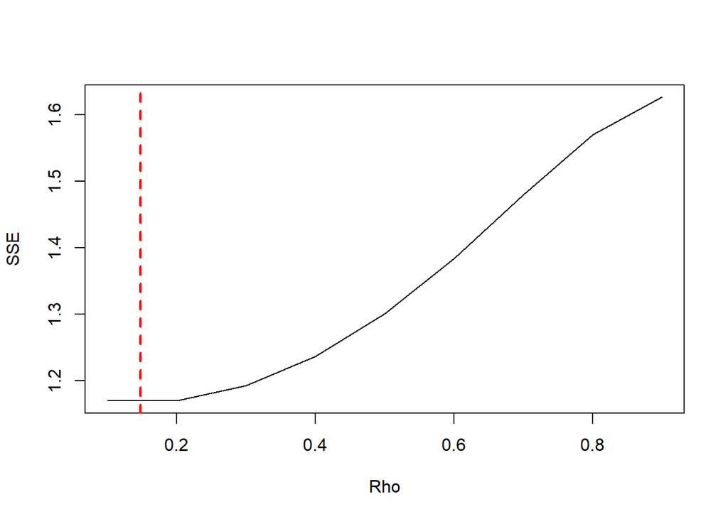

```r
#Grafik SSE optimum
par(mfrow = c(1,1))
plot(tab$SSE ~ tab$rho , type = "l", xlab = "Rho", ylab = "SSE")
abline(v = tabOpt[tabOpt$SSE==min(tabOpt$SSE),"rho"], lty = 2, col="red",lwd=2)
```

```r
#Model terbaik
modelHL <- hildreth.lu.func(0.148,model)
summary(modelHL)
```

```
##
## Call:
## lm(formula = y ~ x1 + x2 + x3)
##
## Residuals:
##       Min        1Q    Median        3Q       Max
## -0.186491 -0.050155  0.008757  0.049502  0.199543
##
## Coefficients:
##             Estimate Std. Error t value Pr(>|t|)
## (Intercept)  0.07366    0.08329   0.884    0.378
## x1          -0.52569    0.05512  -9.537   <2e-16 ***
## x2           0.83630    0.05466  15.301   <2e-16 ***
## x3           0.68261    0.05169  13.207   <2e-16 ***
## ---
## Signif. codes:  0 '***' 0.001 '**' 0.01 '*' 0.05 '.' 0.1 ' ' 1
##
## Residual standard error: 0.07737 on 195 degrees of freedom
## Multiple R-squared:  0.993,  Adjusted R-squared:  0.9929
## F-statistic:  9206 on 3 and 195 DF,  p-value: < 2.2e-16
```

```r
# Deteksi autokorelasi
dwtest(modelHL, alternative='two.sided')
```

```
##
##  Durbin-Watson test
##
## data:  modelHL
## DW = 1.9874, p-value = 0.8765
## alternative hypothesis: true autocorrelation is not 0
```

Berdasarkan hasil di atas diperoleh nilai p-value > 0.05, sehingga tidak tolak H0. Artinya, tidak ada autokorelasi atau terbukti bahwa autokorelasi telah berhasil ditangani menggunakan metode Hildreth-lu.

### Simpulan

Setelah dilakukan pendeteksian autokorelasi pada regresi berganda close stock terhadap open stock, high stock, dan low stock menggunakan Uji Durbin Watson ditemukan adanya autokorelasi sehingga diperlukan adanya penanganan. Terbukti bahwa autokorelasi telah berhasil ditangani menggunakan metode Cochrane-Orcutt dan Hildreth-Lu.